# Assignment #2

Patrick Spauster

2/22/2022

# Short Questions

1. In a 2015 report, an economic consulting firm estimated the economic impacts of constructing a new football stadium in Los Angeles. The authors predicted that if LA receives one NFL team, then the stadium investment would result in 281 million per year in direct spending related to the team (team and stadium operations, player salaries etc). The consulting firm then estimates a total of $507 million per year in total economic impact. What implicit assumptions might they have made in their analysis? Provide a brief assessment of the plausibility of their multiplier.

The economic consulting firm is probably making assumptions about who is spending money at the stadium. In order to produce real economic growth, all of the economic activity would have to be generated from new people coming into the city for activities at the stadium. In reality, there is some substitution effect with people’s leisure spending. Likely, the stadium is replacing recreational spending residents would usually spend elsewhere in the community. For the full multiplier to take effect, the new stadium would have to draw in money from people who are newly coming into a city for stadium events, and staying in the city to spend money at the surrounding businesses.

2. The residents of mobile home parks own their dwellings and rent land from absentee landowners. Consider a city in which all land is currently occupied by mobile home parks. Suppose the city government imposes a 50% tax on land, to be paid (in legal terms) by the person who occupies the land (the tenant). Who actually pays the tax?

Tenants pay this tax. Any landlord will pass on increased land taxes to tenants in the form of higher rents. Since land supply is fixed, the entire tax burden is paid by the occupant.

3. How would you expect the division of land between office firms and manufacturing firms – and their relative locations – to change if per unit freight costs decline (that is, it becomes cheaper to ship manufacturing goods)? Use a single bid-rent diagram to illustrate your answer.

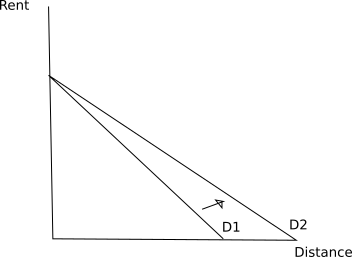

With the decline in freight costs, manufacturing firms would be more willing to locate further from the city center, causing the bid rent curve to move outward. I would also expect the distribution of office firms and manufacturing firms to shift, with a greater proportion of office firms locating close to the city center and a greater proportion of manufacturing firms locating further away.

4. Suppose a city restricts the heights of residential structures. The maximum height is four stories, the height that would normally occur at a distance of five miles from the city center. Draw two residential bid-rent curves on the same graph, one for the city in the absence of height restrictions and one with height restrictions.

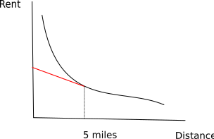

Bid Rent Curve #3

At a distance of 5 miles from the city center, the bid rent curve would straigten out because of the height restriction (indicated by the red line).

# Analysis of Suburbanization in Boston

This exercise requires you to examine suburbanization patterns in the Boston metropolitan area. Using real world data, you will study how the density of population and median household income and poverty rates in Boston area towns change as one moves away from the Boston central business district (CBD) and to examine how these patterns changed between 1970 and 2019 for population and between 1990 and 2019 for income. The required data is posted on Brightspace in an EXCEL file. The data set includes the population for municipalities in the Boston metropolitan area in 1970, 1990, 2000, 2010, and 2019, median household income for 1990, 2000, 2010, and 2019, poverty rates for 2019, as well as their land area and distance to the CBD.

## Calculate the population density for each town in 2019, and plot these densities against distance from the central business district (CBD). Also plot 2019 median income and 2019 poverty rate against distance from the central business district.

Specifically, use EXCEL to create three different XY scatterplot graphs (using the Excel ‘Chart Wizard’). Distance to Boston (the CBD) should be on the x-axis and the density measure (or income/poverty rate) should be on the y-axis:

```
    Population density in 2019
    Median income in 2019
    Poverty rate in 2019
```

Note that density is defined simply as (population/land area).

EXCEL HELP: To create a scatterplot in Excel, the density data must be immediately to the right of the “distance from CBD” column. First create new columns and calculate four density measures for each town in the Boston metropolitan area. Then, you can add two columns for the distance data – one immediately to the left of each density column. Then highlight the data included in a single pair of distance-density columns and click on the Excel Chart Wizard. Choose the custom-type  scatter-plot.

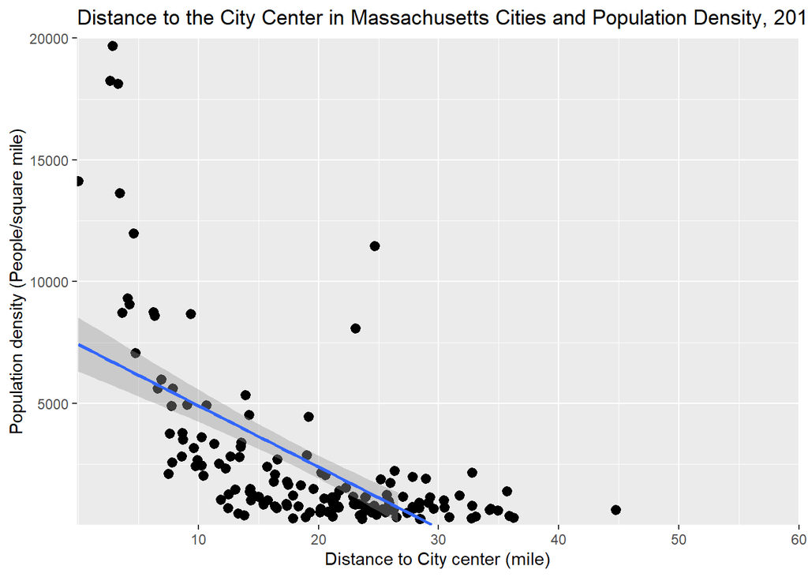

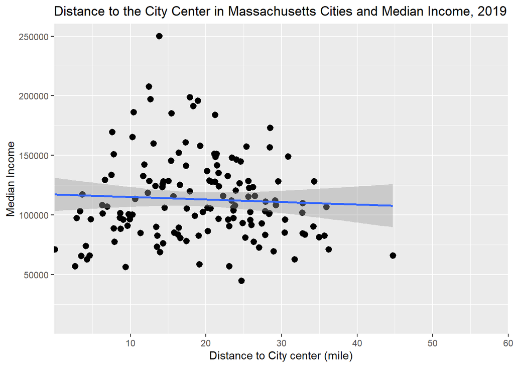

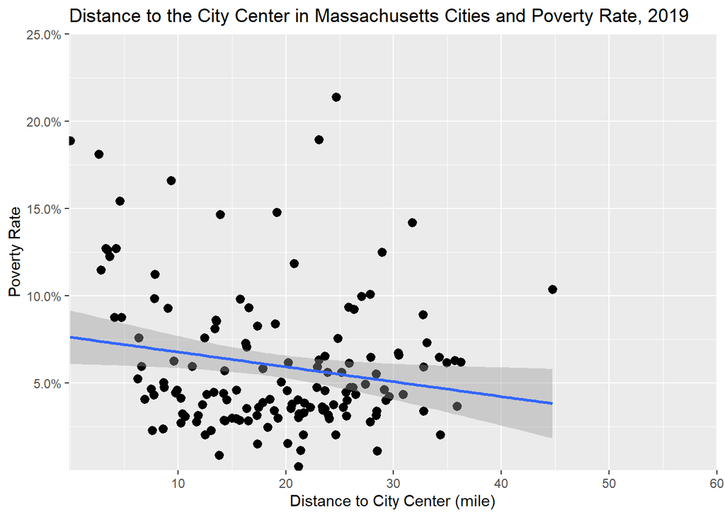

## After producing these graphs, please answer the following questions:

1. Do the graphs generally appear consistent with the predictions of location theory, or the traditional urban model? Why or why not? (Again, take Boston to be the CBD.)

Urban Density is consistent with location theory, with denser populations closer to the city center where land is more expensive, and larger plots of land per person as you get further from the city center. With some outliers, this scatterplot also has the expected convex shape of a bid rent curve.

Median income is relatively constant with respect to distance to the city center. Location theory would predict that high income households would live closer to the city center, but as we’ve discussed in class (and in the literature), reality often doesn’t fit that model, with many poor folks living in city centers and some high income households suburbanizing.

Poverty rates in the metro area are slightly downsloping as distance to the city center increases. While this might not be consistent with location theory (you might expect poorer households to live where land is cheaper), it is consistent with findings in the literature where poor Urban communities persist.

2. Why should population density be higher nearer to the CBD?

Population density should be higher nearer to the CBD because land values are higher. People are willing to trade off higher land rents/acre for lower transportation costs, so they consume less land at a higher price. With each person using less land, there are more people living close together in an area.

3. Are there any notable outliers to population density? What might explain them?

Lawrence and Lowell are notable outliers for density. They have higher population than many of their peers throughout the period 1970-2019. These towns are job centers and small cities in their own right, even if they may be satellite cities of a larger central business district of Boston.

4. What might explain the shape of the income and poverty rate gradients?

The income and poverty gradients are relatively flat compared to what location theory might dictate, where you would expect high income households to live closer to the city center. Policy effects may have a lot to do with this. Over the period America’s suburbanization continued, with the government incentivizing single family homes, towns passing exclusionary zoning to prevent growth, and high income households seeking well funded school systems in suburbs. Compound that with some outright racist policies like redlining that keep poor households of color segregated in particular neighborhoods and limits housing options to select communities within cities, it makes sense why the income and poverty gradients would not perfectly follow the expected patterns of location theory.

Population

5. How many people lived in towns within 15 miles of Boston in 1970, 1990, 2000, and 2019?
6. How many people lived in towns more than 15 miles away from Boston during these four years? (Creating a table like the one below may help.)

| Population 1970 | Population 1990 | Population 2000 | Population 2019 |
| --- | --- | --- | --- |
| 2,361,649 | 2,188,774 | 2,257,395 | 2,485,022 |
| 1,417,106 | 1,670,822 | 1,824,117 | 1,999,192 |

7. What was the percentage change in the population living within 15 miles of Boston during 1970-1990 and from 1990-2019?

8. What was the percentage growth in the population living more than 15 miles away from Boston during these two time periods?

9. What can you say about suburbanization in Boston during these two time periods? How do changes between 1970 and 1990 compare to the changes that occurred between 1990 and 2019? Is the pace of suburbanization similar during each time period?

Income

10. What was the average change in median income less than 5 miles away from Boston, between 5-10 miles away, between 10-15 miles away, and beyond 15 miles between 1990-2000 and between 2010-2019? (In calculating averages, you do not need to weight by population.) Note that you need to calculate the percentage change in median income for each town, and then average those percentages within the distance band.

| Distance to Boston | Average Change in Median Income 1990-2000 | Average Change in Median Income 2010-2019 |
| --- | --- | --- |
| less than 5 miles | 35% | 34% |
| 5-10 miles | 39% | 31% |
| 10-15 miles | 42% | 30% |
| beyond 15 miles | 43% | 25% |

11. What can you say generally about the geography of median income changes in Boston during these two time periods? How do changes between 1990 and 2000 compare to the changes that occurred between 2010 and 2019? How would you explain these differences?

Before the turn of the century, median income grew more the further from the city center. During the 2010s median income grew more closer to the city center. These reflect changing location patterns of high income households, which, as discussed in literature can be due to a number of phenomenon, from high amenity cities, to differences in education, to the scarcity of leisure time, to changes in household composition and family creation, all of which might contribute to changes in welathy household’s preferences for living in the city versus in the suburbs.

12. REQUIRED FOR URBAN PLANNING STUDENTS:

Using the .shp files posted on NYU Classes, create three maps using GIS: 1) percent growth in population from 1970-2019, 2) 2019 median income, and 3) 2019 poverty rate, for all the jurisdictions in the Boston Metro Area. Do the maps tell you anything that the numbers and graphs did not?

Note: Don’t worry if there are 2-3 missing geographies in the output map.

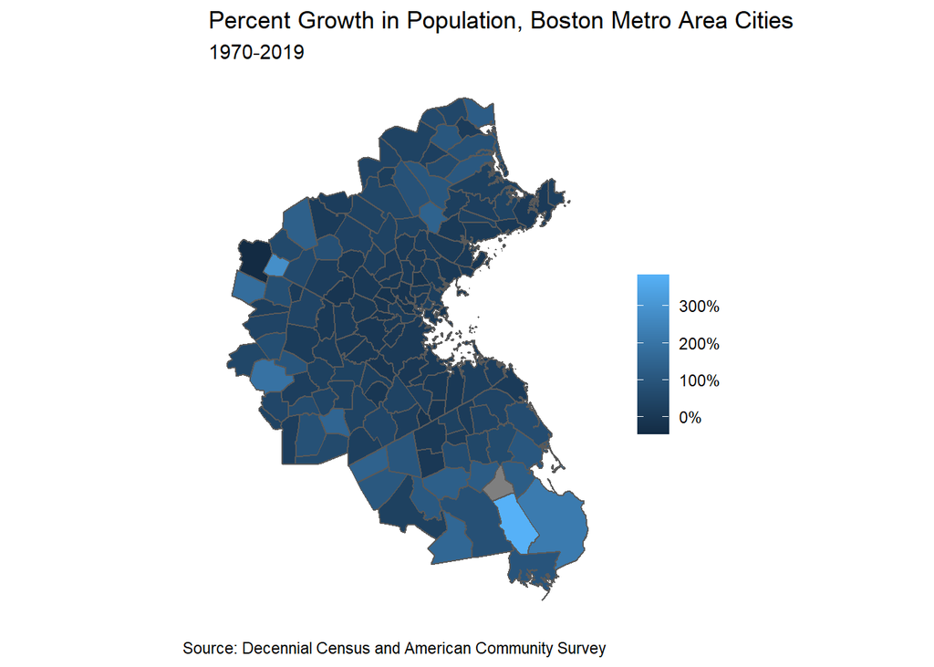

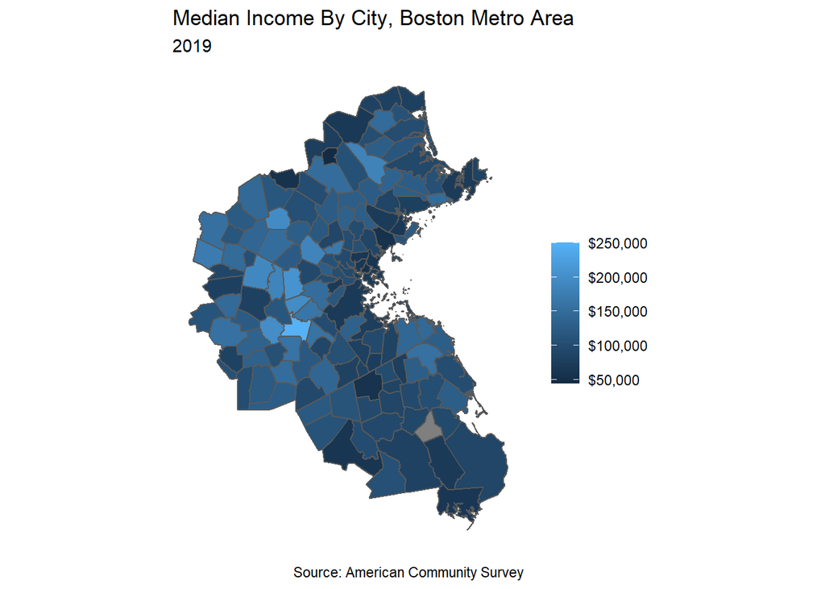

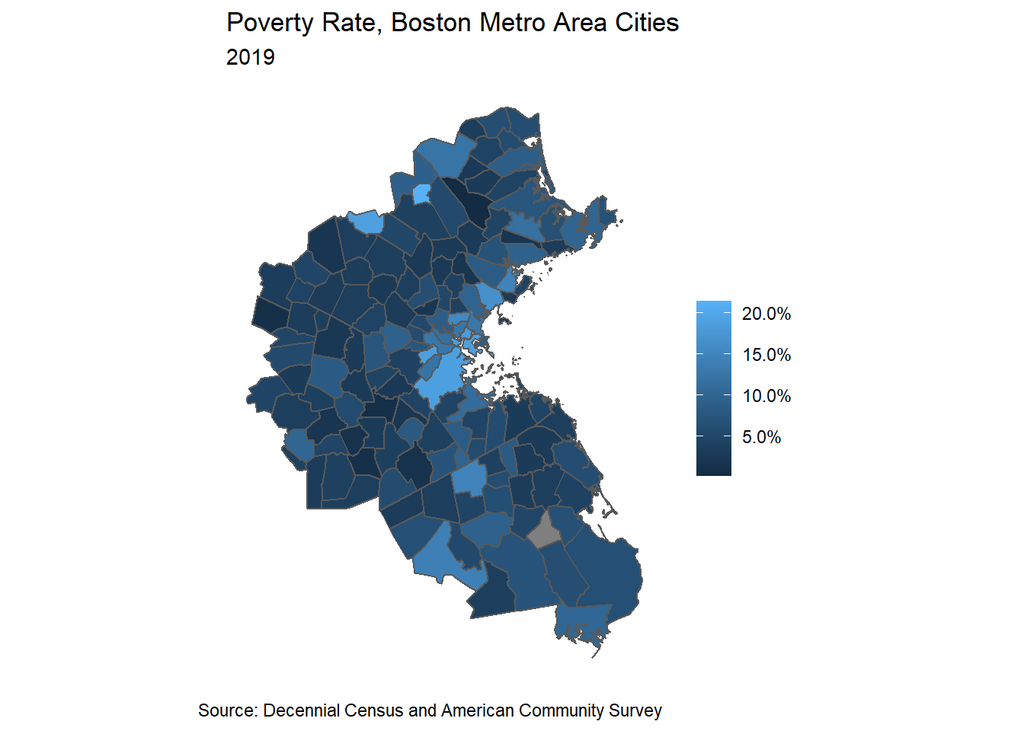